# I) Deep Learning and Keras

[figure not shown]

```python
%matplotlib inline
import matplotlib.pyplot as plt
import matplotlib.image as mpimg
image = mpimg.imread("/home/mrclnndrd/Dropbox/Projetos/Radiomics/Imagens/im4.png")
plt.figure(figsize=(15,15))
plt.subplot(1,1,1)
plt.imshow(image)
plt.show()
```

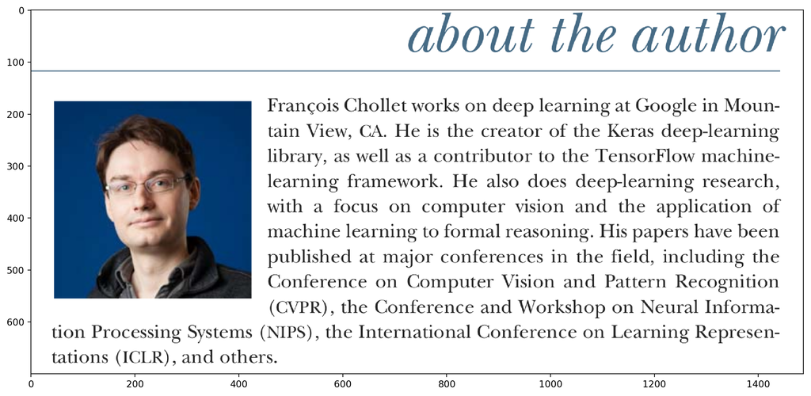

```python
import matplotlib.pyplot as plt
import matplotlib.image as mpimg

import matplotlib as mpl
mpl.rcParams['figure.dpi'] = 200

image = mpimg.imread("/home/mrclnndrd/Dropbox/Projetos/Radiomics/Imagens/im5.png")
plt.figure(figsize=(15,15))
plt.subplot(1,1,1)
plt.imshow(image)
plt.show()
```

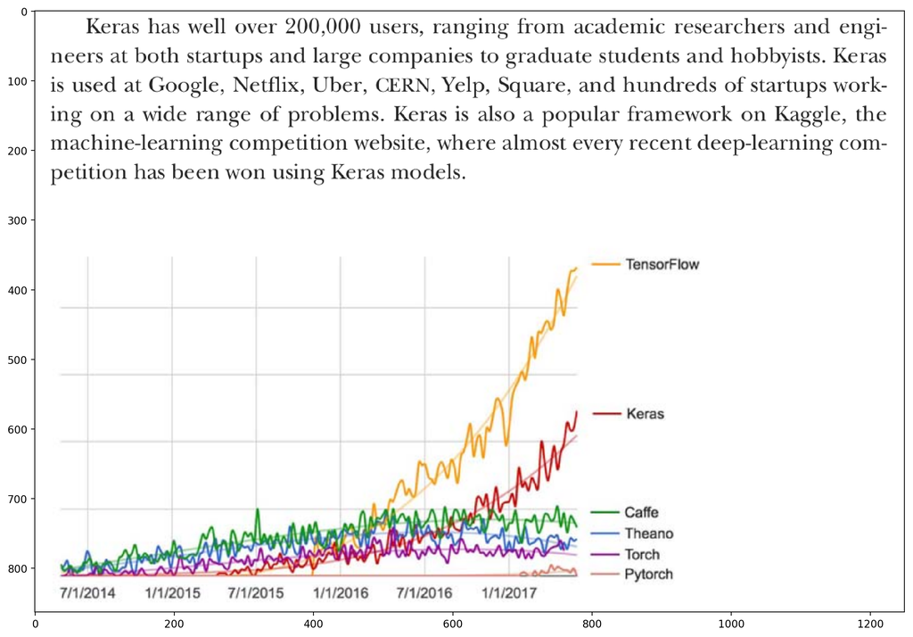

```python
import matplotlib.pyplot as plt
import matplotlib.image as mpimg
image = mpimg.imread("/home/mrclnndrd/Dropbox/Projetos/Radiomics/Imagens/im1.png")
plt.figure(figsize=(15,15))
plt.subplot(1,1,1)
plt.imshow(image)
plt.show()
```

# II) Anatomy of a neural network

> Layers, which are combined into a network (or model)

> The input data and corresponding targets

> The loss function, which defines the feedback signal used for learning

> The optimizer, which determines how learning proceeds

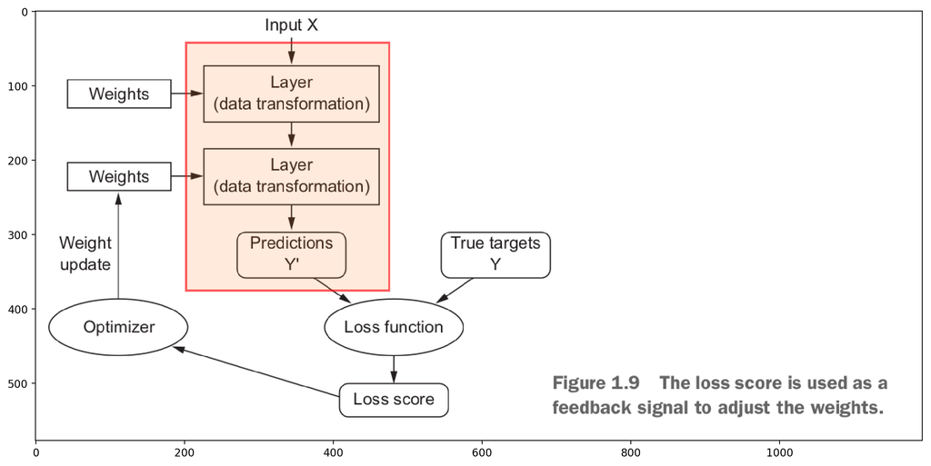

```python
image = mpimg.imread("/home/mrclnndrd/Dropbox/Projetos/Radiomics/Imagens/im3.png")
plt.figure(figsize=(15,15))
plt.subplot(1,1,1)
plt.imshow(image)
plt.show()
```

# You can think of a deep network as a multistage information-distillation operation, where information goes through successive filters and comes out increasingly purified

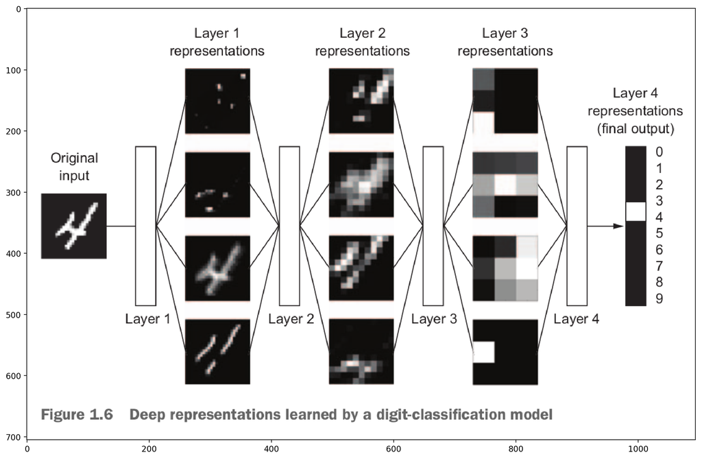

```python
image = mpimg.imread("/home/mrclnndrd/Dropbox/Projetos/Radiomics/Imagens/im2.png")
plt.figure(figsize=(15,15))
plt.subplot(1,1,1)
plt.imshow(image)
plt.show()
```

# 1) Loading the MNIST dataset in Keras

Let’s look at a concrete example of a neural network that uses the Python library Keras to learn to classify handwritten digits.

The problem we’re trying to solve here is to classify grayscale images of handwritten digits (28 × 28 pixels) into their 10 categories (0 through 9). We’ll use the MNIST (Modified National Institute of Standards and Technology database) dataset, a classic in the machine-learning community, which has been around almost as long as the field itself and has been intensively studied.

It’s a set of 60,000 training images, plus 10,000 test images, assembled by the National Institute of Standards and Technology (the NIST in MNIST ) in the 1980s. You can think of “solving” MNIST as the “Hello World” of deep learning.

```python
from keras.datasets import mnist

(train_images, train_labels), (test_images, test_labels) = mnist.load_data()
```

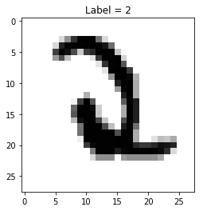

```
[(60000, 28, 28), (10000, 28, 28)]
```

```python
%matplotlib inline
number=400
digit = train_images[number]
import matplotlib.pyplot as plt
plt.imshow(digit, cmap=plt.cm.binary)
plt.title("Label = "+ str(train_labels[number]))
plt.show()
[train_images.shape, test_images.shape]
```

# 1.2) The network architecture

```python
from keras import models
from keras import layers
import tensorflow as tf


network = models.Sequential()

network.add(layers.Dense(512, activation='relu', input_shape=(28 * 28,)))
network.add(layers.Dense(10, activation = (tf.nn.softmax)))
network.summary()
```

```
_________________________________________________________________
Layer (type)                 Output Shape              Param #
=================================================================
dense_1 (Dense)              (None, 512)               401920
_________________________________________________________________
dense_2 (Dense)              (None, 10)                5130
=================================================================
Total params: 407,050
Trainable params: 407,050
Non-trainable params: 0
_________________________________________________________________
```

# 1.3) The compilation step

```python
network.compile(optimizer='rmsprop',loss='categorical_crossentropy', metrics=['accuracy'])
```

# 1.4) Preparing the image data

```python
train_images = train_images.reshape((60000, 28 * 28))
train_images = train_images.astype('float32') / 255
test_images = test_images.reshape((10000, 28 * 28))
test_images = test_images.astype('float32') / 255
```

# 1.5) Preparing the labels

```python
from keras.utils import to_categorical
train_labels = to_categorical(train_labels)
test_labels = to_categorical(test_labels)
```

# 1.6) Training data

```python
network.fit(train_images, train_labels, epochs=5, batch_size=128)
```

```
<keras.callbacks.History at 0x7f74584a56d8>
```

# 1.7) The model performs

```python
test_loss, test_acc = network.evaluate(test_images, test_labels)
print('test_acc:', test_acc)
```

```
test_acc: 0.9765
```

# 2) Loading the IMDB dataset in Keras

You’ll work with the IMDB (The Internet Movie Database) dataset: a set of 50,000 highly polarized reviews from the Internet Movie Database. They’re split into 25,000 reviews for training and 25,000 reviews for testing, each set consisting of 50% negative and 50% positive reviews.

```python
from keras.datasets import imdb
(train_data, train_labels), (test_data, test_labels) = imdb.load_data(num_words=10000)
```

# 2.1) Decodes the review

```python
movie=0
print(train_data[movie][:10000])
word_index = imdb.get_word_index()
reverse_word_index = dict([(value, key) for (key, value) in word_index.items()])
decoded_review = ' '.join([reverse_word_index.get(i - 3, '?') for i in train_data[movie]])
decoded_review
```

```
[1, 14, 22, 16, 43, 530, 973, 1622, 1385, 65, 458, 4468, 66, 3941, 4, 173, 36, 256, 5, 25, 100, 43, 838, 112, 50, 670, 2, 9, 35, 480, 284, 5, 150, 4, 172, 112, 167, 2, 336, 385, 39, 4, 172, 4536, 1111, 17, 546, 38, 13, 447, 4, 192, 50, 16, 6, 147, 2025, 19, 14, 22, 4, 1920, 4613, 469, 4, 22, 71, 87,…
```

```
"? this film was just brilliant casting location scenery story direction everyone's really suited the part they played and you could just imagine being there robert ? is an amazing actor and now the same being director ? father came from the same scottish island as myself so i loved the fact there w…
```

```python
test_labels[movie]
```

```
0
```